# FOCUS designs coils for a finite-beta equilibrium

Unlike vacuum configurations, a finite-beta equilibrium usually has non-zero plasma currents. This implies the plasma currents will contribute to the normal field on the plasma boundary. The basic logic is to calculate the normal field from plasma currents and save it as an input to FOCUS. FOCUS will design coils satisfying the boundary conditions.

Here we are going to use the BNORM code calculating the required normal field from plasma currents read from a VMEC output. The most important part is to make sure you are using the correct sign and normalization. There is a detailed discussion about the coodinate systems and normalizations in several different codes, please check Coil_design_codes_benchmark.

We use the NCSX C09R00 configuration as a reference. The files can be found in `examples/ncsx_c09r00`.

1. Prepare FOCUS input Here we use the function [`vmec2focus`](https://github.com/zhucaoxiang/CoilPy/blob/master/coilpy/misc.py#L231) in the python package CoilPy.

   ```
   from coilpy import vmec2focus
    vmec2focus('wout_c09r00_fb.nc', focus_file='c09r00.boundary', bnorm_file='bnorm.c09r00_fb')
   ```

2. Run FOCUS with actual coils and generate a MGRID file

   ```
    mpiexec xfocus actual
   ```

3. Run free-boundary VMEC with FOCUS written MGRID file

   ```
    mpiexec xvmec2000 input.c09r00_focus
   ```

**Note:**

1. Right now, FOCUS cannot constrain the total poloildal current. This might cause trouble when doing equilibrium reconstruction. It is suggested to fix the coil currents.
2. If you are using FAMUS, you have to specify `flipsign=True` in the arguments because FAMUS adds the input Bn.

# Check FOCUS results

Here is the screen output of this FOCUS run.

```
diagnos :      Bnormal ; Bmn harmonic ;    tor. flux ;  coil length ;     c-s sep. ;         curv ;
        :  3.02591E-04 ;  0.00000E+00 ;  0.00000E+00 ;  0.00000E+00 ;  0.00000E+00 ;  1.00835E-01 ;
        : Maximum curvature of all the coils is  :  1.295706752408570E+01 ; at coil   3
        : Average curvature of the coils is      :  2.437259690939244E+00
        : Average length of the coils is         :  5.735684027399017E+00
        : The minimum coil-coil distance is      :  8.838352429874008E-02 ; at coils 52 , 50
        : The minimum coil-plasma distance is    :  2.036187538974496E-01 ; at coil   2
        : Ave. relative absolute Bn error |Bn|/B :  5.17696E-03; max(|Bn|)= 5.18986E-02
        : Surface area normalized Bn error int(|Bn|/B*ds)/A :   5.187074499286478E-03
wtmgrid : writing mgrid file at grid of [  6.00000E-01   2.40000E+00  -1.00000E+00   1.00000E+00   ]   121   101   101
wtmgrid : writing mgrid.focus_actual ; Mfp=  3 ;
focus   : Post-processing took  1.40687E+01 S.
```

```python
import matplotlib.pyplot as plt
import numpy as np
from coilpy import *
focus = FourSurf.read_focus_input('c09r00.boundary')
```

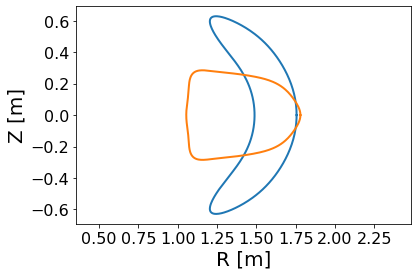

```python
plt.figure()
focus.plot()
focus.plot(zeta=np.pi/3)
```

[output not shown]

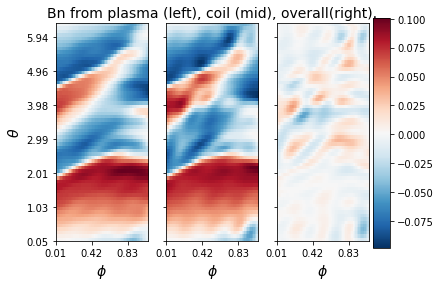

```python
actual = FOCUSHDF5('focus_actual.h5')
actual.Bnorm()
```